# Student alcohol consumption

Marek Fudaliński && Jakub Sroka

5/13/2020

## Dataset

dataset obtained from: https://www.kaggle.com/uciml/student-alcohol-consumption

### Context:

The data were obtained in a survey of students math courses in secondary school. It contains a lot of interesting social, gender and study information about students. You can use it for some EDA or try to predict students final grade.

In ths notebook we will be trying to predict student alcohol consumption based on available data

school - student’s school (binary: ‘GP’ - Gabriel Pereira or ‘MS’ - Mousinho da Silveira)  
sex - student’s sex (binary: ‘F’ - female or ‘M’ - male)  
age - student’s age (numeric: from 15 to 22)  
address - student’s home address type (binary: ‘U’ - urban or ‘R’ - rural)  
famsize - family size (binary: ‘LE3’ - less or equal to 3 or ‘GT3’ - greater than 3)  
Pstatus - parent’s cohabitation status (binary: ‘T’ - living together or ‘A’ - apart)  
Medu - mother’s education (numeric: 0 - none, 1 - primary education (4th grade), 2 – 5th to 9th grade, 3 – secondary education or 4 – higher education)  
Fedu - father’s education (numeric: 0 - none, 1 - primary education (4th grade), 2 – 5th to 9th grade, 3 – secondary education or 4 – higher education)  
Mjob - mother’s job (nominal: ‘teacher’, ‘health’ care related, civil ‘services’ (e.g. administrative or police), ‘at_home’ or ‘other’)  
Fjob - father’s job (nominal: ‘teacher’, ‘health’ care related, civil ‘services’ (e.g. administrative or police), ‘at_home’ or ‘other’)  
reason - reason to choose this school (nominal: close to ‘home’, school ‘reputation’, ‘course’ preference or ‘other’)  
guardian - student’s guardian (nominal: ‘mother’, ‘father’ or ‘other’)  
traveltime - home to school travel time (numeric: 1 - 1 hour)  
studytime - weekly study time (numeric: 1 - 10 hours)  
failures - number of past class failures (numeric: n if 1<=n<3, else 4)  
schoolsup - extra educational support (binary: yes or no)  
famsup - family educational support (binary: yes or no)  
paid - extra paid classes within the course subject (Math or Portuguese) (binary: yes or no)  
activities - extra-curricular activities (binary: yes or no)  
nursery - attended nursery school (binary: yes or no)  
higher - wants to take higher education (binary: yes or no)  
internet - Internet access at home (binary: yes or no)  
romantic - with a romantic relationship (binary: yes or no)  
famrel - quality of family relationships (numeric: from 1 - very bad to 5 - excellent)  
freetime - free time after school (numeric: from 1 - very low to 5 - very high)  
goout - going out with friends (numeric: from 1 - very low to 5 - very high)  
Dalc - workday alcohol consumption (numeric: from 1 - very low to 5 - very high)  
Walc - weekend alcohol consumption (numeric: from 1 - very low to 5 - very high)  
health - current health status (numeric: from 1 - very bad to 5 - very good)  
absences - number of school absences (numeric: from 0 to 93)

These grades are related with the Math course:

G1 - first period grade (numeric: from 0 to 20)  
G2 - second period grade (numeric: from 0 to 20)  
G3 - final grade (numeric: from 0 to 20, output target)

## First look at dataset

```r
matStudentds <- read.csv("data/student-mat.csv", header = TRUE)
head(matStudentds, 3)
```

```
##   school sex age address famsize Pstatus Medu Fedu    Mjob    Fjob reason
## 1     GP   F  18       U     GT3       A    4    4 at_home teacher course
## 2     GP   F  17       U     GT3       T    1    1 at_home   other course
## 3     GP   F  15       U     LE3       T    1    1 at_home   other  other
##   guardian traveltime studytime failures schoolsup famsup paid activities
## 1   mother          2         2        0       yes     no   no         no
## 2   father          1         2        0        no    yes   no         no
## 3   mother          1         2        3       yes     no  yes         no
##   nursery higher internet romantic famrel freetime goout Dalc Walc health
## 1     yes    yes       no       no      4        3     4    1    1      3
## 2      no    yes      yes       no      5        3     3    1    1      3
## 3     yes    yes      yes       no      4        3     2    2    3      3
##   absences G1 G2 G3
## 1        6  5  6  6
## 2        4  5  5  6
## 3       10  7  8 10
```

```r
summary(matStudentds)
```

```
##  school   sex          age       address famsize   Pstatus      Medu
##  GP:349   F:208   Min.   :15.0   R: 88   GT3:281   A: 41   Min.   :0.000
##  MS: 46   M:187   1st Qu.:16.0   U:307   LE3:114   T:354   1st Qu.:2.000
##                   Median :17.0                             Median :3.000
##                   Mean   :16.7                             Mean   :2.749
##                   3rd Qu.:18.0                             3rd Qu.:4.000
##                   Max.   :22.0                             Max.   :4.000
##       Fedu             Mjob           Fjob            reason      guardian
##  Min.   :0.000   at_home : 59   at_home : 20   course    :145   father: 90
##  1st Qu.:2.000   health  : 34   health  : 18   home      :109   mother:273
##  Median :2.000   other   :141   other   :217   other     : 36   other : 32
##  Mean   :2.522   services:103   services:111   reputation:105
##  3rd Qu.:3.000   teacher : 58   teacher : 29
##  Max.   :4.000
##    traveltime      studytime        failures      schoolsup famsup     paid
##  Min.   :1.000   Min.   :1.000   Min.   :0.0000   no :344   no :153   no :214
##  1st Qu.:1.000   1st Qu.:1.000   1st Qu.:0.0000   yes: 51   yes:242   yes:181
##  Median :1.000   Median :2.000   Median :0.0000
##  Mean   :1.448   Mean   :2.035   Mean   :0.3342
##  3rd Qu.:2.000   3rd Qu.:2.000   3rd Qu.:0.0000
##  Max.   :4.000   Max.   :4.000   Max.   :3.0000
##  activities nursery   higher    internet  romantic      famrel
##  no :194    no : 81   no : 20   no : 66   no :263   Min.   :1.000
##  yes:201    yes:314   yes:375   yes:329   yes:132   1st Qu.:4.000
##                                                     Median :4.000
##                                                     Mean   :3.944
##                                                     3rd Qu.:5.000
##                                                     Max.   :5.000
##     freetime         goout            Dalc            Walc
##  Min.   :1.000   Min.   :1.000   Min.   :1.000   Min.   :1.000
##  1st Qu.:3.000   1st Qu.:2.000   1st Qu.:1.000   1st Qu.:1.000
##  Median :3.000   Median :3.000   Median :1.000   Median :2.000
##  Mean   :3.235   Mean   :3.109   Mean   :1.481   Mean   :2.291
##  3rd Qu.:4.000   3rd Qu.:4.000   3rd Qu.:2.000   3rd Qu.:3.000
##  Max.   :5.000   Max.   :5.000   Max.   :5.000   Max.   :5.000
##      health         absences            G1              G2
##  Min.   :1.000   Min.   : 0.000   Min.   : 3.00   Min.   : 0.00
##  1st Qu.:3.000   1st Qu.: 0.000   1st Qu.: 8.00   1st Qu.: 9.00
##  Median :4.000   Median : 4.000   Median :11.00   Median :11.00
##  Mean   :3.554   Mean   : 5.709   Mean   :10.91   Mean   :10.71
##  3rd Qu.:5.000   3rd Qu.: 8.000   3rd Qu.:13.00   3rd Qu.:13.00
##  Max.   :5.000   Max.   :75.000   Max.   :19.00   Max.   :19.00
##        G3
##  Min.   : 0.00
##  1st Qu.: 8.00
##  Median :11.00
##  Mean   :10.42
##  3rd Qu.:14.00
##  Max.   :20.00
```

## Data Preparation

```r
matStudentds$alc <- ceiling((as.numeric(matStudentds$Walc) + as.numeric(matStudentds$Dalc)) / 2)
matStudentds$alc
```

```
##   [1] 1 1 3 1 2 2 1 1 1 1 2 1 2 2 1 2 2 1 3 2 1 1 2 3 1 2 2 3 1 5 4 1 1 1 1 1 1
##  [38] 1 1 1 2 3 1 1 2 1 3 1 2 1 3 1 4 3 4 1 1 1 1 1 3 5 1 3 3 2 5 2 2 3 1 1 3 2
##  [75] 3 3 1 2 1 2 2 2 1 2 3 3 2 2 1 4 2 2 3 1 1 1 1 1 2 1 5 1 1 1 1 1 1 1 4 1 1
## [112] 1 1 1 1 2 1 1 3 2 2 2 2 3 1 3 1 1 2 4 2 2 2 3 1 1 3 1 2 1 1 2 1 3 2 2 1 1
## [149] 2 4 4 4 3 1 1 1 3 3 2 4 2 3 3 3 3 1 3 1 1 1 3 1 2 1 1 4 3 3 4 1 3 2 3 3 2
## [186] 3 2 2 2 3 1 1 5 4 1 1 2 4 3 2 3 2 2 2 1 4 2 1 3 1 2 5 1 3 2 2 3 3 3 1 2 1
## [223] 1 5 1 1 2 2 5 2 2 1 2 3 1 2 5 1 1 4 3 3 1 2 1 1 1 5 2 3 3 2 4 2 3 2 1 1 2
## [260] 1 2 1 1 1 1 4 4 2 2 2 3 2 1 2 1 3 1 3 1 2 3 4 1 1 2 2 2 1 2 1 3 2 1 1 1 2
## [297] 3 2 1 2 1 2 1 2 1 1 1 1 2 2 2 1 2 2 1 1 2 1 4 3 2 1 2 3 3 2 4 5 2 2 3 1 1
## [334] 1 1 2 2 3 1 3 2 2 2 2 2 3 2 3 2 5 3 3 3 3 2 1 2 2 2 1 3 3 2 1 2 3 2 2 2 3
## [371] 1 3 1 2 1 2 1 4 2 3 3 2 1 2 4 2 2 2 1 1 5 4 3 4 3
```

```r
data <- subset(matStudentds, select = -c(Walc, Dalc))
head(data, 1)
```

```
##   school sex age address famsize Pstatus Medu Fedu    Mjob    Fjob reason
## 1     GP   F  18       U     GT3       A    4    4 at_home teacher course
##   guardian traveltime studytime failures schoolsup famsup paid activities
## 1   mother          2         2        0       yes     no   no         no
##   nursery higher internet romantic famrel freetime goout health absences G1 G2
## 1     yes    yes       no       no      4        3     4      3        6  5  6
##   G3 alc
## 1  6   1
```

### Linear regression to find alcohol consumption

```r
library(MASS)
attach(data)
lmFit <- lm(alc ~ ., data = data)
summary(lmFit)
```

```
##
## Call:
## lm(formula = alc ~ ., data = data)
##
## Residuals:
##      Min       1Q   Median       3Q      Max
## -2.62335 -0.56804 -0.09586  0.49833  2.71890
##
## Coefficients:
##                   Estimate Std. Error t value Pr(>|t|)
## (Intercept)       0.073095   0.985267   0.074 0.940902
## schoolMS         -0.087958   0.170754  -0.515 0.606791
## sexM              0.428128   0.105485   4.059 6.08e-05 ***
## age               0.074763   0.046927   1.593 0.112013
## addressU         -0.264673   0.125376  -2.111 0.035469 *
## famsizeLE3        0.193019   0.104975   1.839 0.066795 .
## PstatusT         -0.104152   0.156246  -0.667 0.505469
## Medu              0.000297   0.069197   0.004 0.996578
## Fedu              0.053820   0.059727   0.901 0.368147
## Mjobhealth       -0.327230   0.239923  -1.364 0.173466
## Mjobother        -0.195304   0.154134  -1.267 0.205949
## Mjobservices     -0.187781   0.171888  -1.092 0.275374
## Mjobteacher      -0.163793   0.224038  -0.731 0.465205
## Fjobhealth        0.112741   0.310475   0.363 0.716730
## Fjobother         0.261233   0.219932   1.188 0.235711
## Fjobservices      0.503139   0.228009   2.207 0.027979 *
## Fjobteacher      -0.015937   0.280043  -0.057 0.954650
## reasonhome        0.040704   0.119472   0.341 0.733531
## reasonother       0.384476   0.175464   2.191 0.029090 *
## reasonreputation -0.000782   0.124418  -0.006 0.994989
## guardianmother   -0.178875   0.117453  -1.523 0.128664
## guardianother    -0.430955   0.214106  -2.013 0.044891 *
## traveltime        0.125487   0.073135   1.716 0.087070 .
## studytime        -0.156799   0.062361  -2.514 0.012367 *
## failures          0.061627   0.074933   0.822 0.411387
## schoolsupyes     -0.049823   0.148809  -0.335 0.737964
## famsupyes        -0.052560   0.104209  -0.504 0.614316
## paidyes           0.313970   0.102089   3.075 0.002265 **
## activitiesyes    -0.228897   0.095672  -2.393 0.017254 *
## nurseryyes       -0.252573   0.117607  -2.148 0.032424 *
## higheryes         0.183687   0.232627   0.790 0.430277
## internetyes       0.074123   0.133819   0.554 0.579994
## romanticyes      -0.037065   0.102531  -0.361 0.717943
## famrel           -0.179511   0.052844  -3.397 0.000759 ***
## freetime          0.071150   0.050800   1.401 0.162207
## goout             0.314195   0.044729   7.024 1.11e-11 ***
## health            0.069991   0.034676   2.018 0.044302 *
## absences          0.015201   0.006295   2.415 0.016255 *
## G1               -0.027429   0.029347  -0.935 0.350618
## G2                0.011565   0.034363   0.337 0.736658
## G3                0.008316   0.024696   0.337 0.736510
## ---
## Signif. codes:  0 '***' 0.001 '**' 0.01 '*' 0.05 '.' 0.1 ' ' 1
##
## Residual standard error: 0.8852 on 354 degrees of freedom
## Multiple R-squared:  0.3834, Adjusted R-squared:  0.3138
## F-statistic: 5.504 on 40 and 354 DF,  p-value: < 2.2e-16
```

Based on regresssion on all parametrs now we can check which parameters are significant and create a subset of the for further analysis. Just based on this test we can assume that the biggest risk of excesive alcohol consumptions exists within males that have bad relationship with their family, and often go out with their friends. This assumptions seems reasonable even without tests.

### Slimer model

```r
dataFiltered <-  subset(data, select =  c(sex, address, Fjob, reason, paid, activities, nursery, famrel, goout, health, absences, alc))
detach(data)
attach(dataFiltered)
head(dataFiltered, 1)
```

```
##   sex address    Fjob reason paid activities nursery famrel goout health
## 1   F       U teacher course   no         no     yes      4     4      3
##   absences alc
## 1        6   1
```

```r
lmSlimFit <- lm(alc ~ ., data = dataFiltered)
summary(lmSlimFit)
```

```
##
## Call:
## lm(formula = alc ~ ., data = dataFiltered)
##
## Residuals:
##     Min      1Q  Median      3Q     Max
## -2.5365 -0.5828 -0.1038  0.4850  3.0861
##
## Coefficients:
##                   Estimate Std. Error t value Pr(>|t|)
## (Intercept)       1.291788   0.346020   3.733 0.000218 ***
## sexM              0.563071   0.093538   6.020 4.14e-09 ***
## addressU         -0.313925   0.110532  -2.840 0.004753 **
## Fjobhealth       -0.023874   0.294821  -0.081 0.935503
## Fjobother         0.186121   0.211360   0.881 0.379101
## Fjobservices      0.444971   0.219300   2.029 0.043154 *
## Fjobteacher      -0.046996   0.261428  -0.180 0.857432
## reasonhome       -0.016756   0.117100  -0.143 0.886294
## reasonother       0.380665   0.169553   2.245 0.025339 *
## reasonreputation -0.092533   0.120522  -0.768 0.443101
## paidyes           0.260806   0.093237   2.797 0.005418 **
## activitiesyes    -0.260223   0.091801  -2.835 0.004834 **
## nurseryyes       -0.243248   0.112980  -2.153 0.031950 *
## famrel           -0.179328   0.050817  -3.529 0.000469 ***
## goout             0.351318   0.040916   8.586 2.38e-16 ***
## health            0.064708   0.033493   1.932 0.054107 .
## absences          0.017862   0.005743   3.110 0.002013 **
## ---
## Signif. codes:  0 '***' 0.001 '**' 0.01 '*' 0.05 '.' 0.1 ' ' 1
##
## Residual standard error: 0.8919 on 378 degrees of freedom
## Multiple R-squared:  0.3317, Adjusted R-squared:  0.3034
## F-statistic: 11.72 on 16 and 378 DF,  p-value: < 2.2e-16
```

Since only paramater that left and is not category type field is no. absences we will check if there are some other than linear relations between this value and alc.

```r
ab <- lm(alc ~ poly(absences, 3))
summary(ab)
```

```
##
## Call:
## lm(formula = alc ~ poly(absences, 3))
##
## Residuals:
##     Min      1Q  Median      3Q     Max
## -1.5320 -0.7955 -0.0517  0.7133  3.2045
##
## Coefficients:
##                    Estimate Std. Error t value Pr(>|t|)
## (Intercept)         2.05316    0.05262  39.021  < 2e-16 ***
## poly(absences, 3)1  2.99083    1.04574   2.860 0.004463 **
## poly(absences, 3)2 -3.50746    1.04574  -3.354 0.000874 ***
## poly(absences, 3)3  1.02480    1.04574   0.980 0.327704
## ---
## Signif. codes:  0 '***' 0.001 '**' 0.01 '*' 0.05 '.' 0.1 ' ' 1
##
## Residual standard error: 1.046 on 391 degrees of freedom
## Multiple R-squared:  0.04956,    Adjusted R-squared:  0.04227
## F-statistic: 6.797 on 3 and 391 DF,  p-value: 0.0001779
```

We can observer significant relation up to second power, further results give high lvl of Pr(>|t|) and shouldn’t be included.

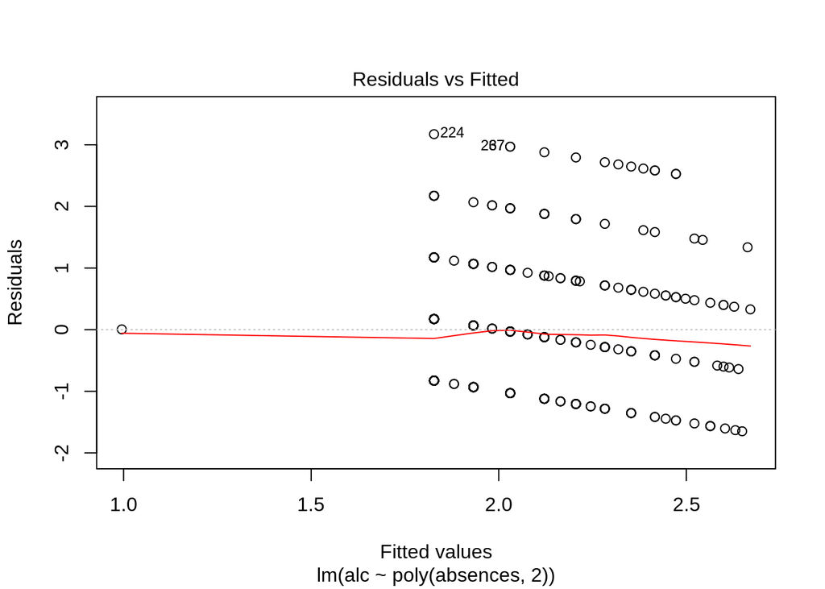

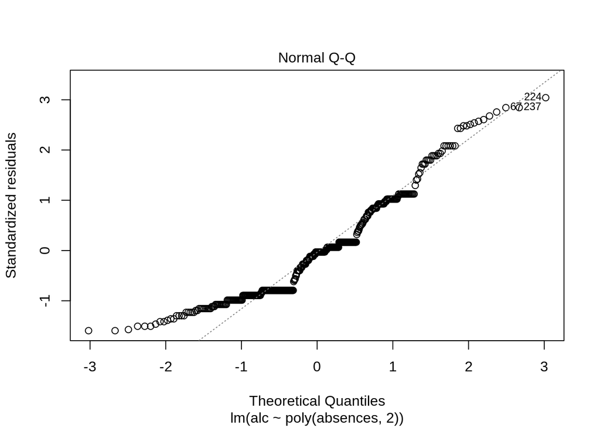

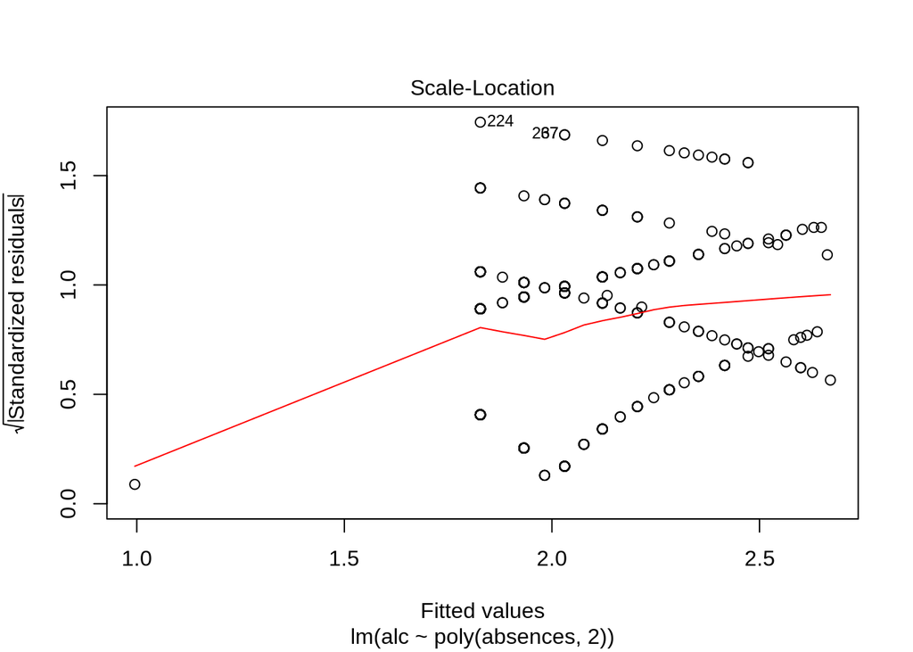

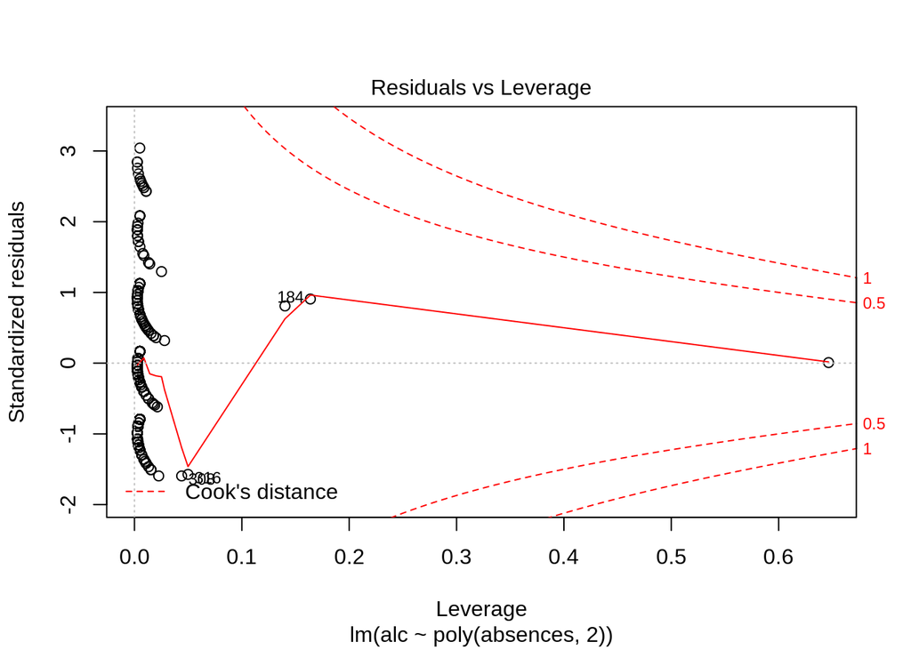

```r
absenc <- lm(alc ~ poly(absences, 2))
plot(absenc)
```

## Logistic prediction

```r
dataFilteredProblem <- dataFiltered
detach(dataFiltered)
dataFilteredProblem$alcProblem <- dataFiltered$alc > 2
dataFilteredProblem$alcProblem
```

```
##   [1] FALSE FALSE  TRUE FALSE FALSE FALSE FALSE FALSE FALSE FALSE FALSE FALSE
##  [13] FALSE FALSE FALSE FALSE FALSE FALSE  TRUE FALSE FALSE FALSE FALSE  TRUE
##  [25] FALSE FALSE FALSE  TRUE FALSE  TRUE  TRUE FALSE FALSE FALSE FALSE FALSE
##  [37] FALSE FALSE FALSE FALSE FALSE  TRUE FALSE FALSE FALSE FALSE  TRUE FALSE
##  [49] FALSE FALSE  TRUE FALSE  TRUE  TRUE  TRUE FALSE FALSE FALSE FALSE FALSE
##  [61]  TRUE  TRUE FALSE  TRUE  TRUE FALSE  TRUE FALSE FALSE  TRUE FALSE FALSE
##  [73]  TRUE FALSE  TRUE  TRUE FALSE FALSE FALSE FALSE FALSE FALSE FALSE FALSE
##  [85]  TRUE  TRUE FALSE FALSE FALSE  TRUE FALSE FALSE  TRUE FALSE FALSE FALSE
##  [97] FALSE FALSE FALSE FALSE  TRUE FALSE FALSE FALSE FALSE FALSE FALSE FALSE
## [109]  TRUE FALSE FALSE FALSE FALSE FALSE FALSE FALSE FALSE FALSE  TRUE FALSE
## [121] FALSE FALSE FALSE  TRUE FALSE  TRUE FALSE FALSE FALSE  TRUE FALSE FALSE
## [133] FALSE  TRUE FALSE FALSE  TRUE FALSE FALSE FALSE FALSE FALSE FALSE  TRUE
## [145] FALSE FALSE FALSE FALSE FALSE  TRUE  TRUE  TRUE  TRUE FALSE FALSE FALSE
## [157]  TRUE  TRUE FALSE  TRUE FALSE  TRUE  TRUE  TRUE  TRUE FALSE  TRUE FALSE
## [169] FALSE FALSE  TRUE FALSE FALSE FALSE FALSE  TRUE  TRUE  TRUE  TRUE FALSE
```

[output cut: 18 more lines]

```r
dataFilteredProblem <- subset(dataFilteredProblem, select = -c(alc))

smp_size <- floor(0.8 * nrow(dataFilteredProblem))

set.seed(123)
train_ind <- sample(seq_len(nrow(dataFilteredProblem)), size = smp_size)

train <- dataFilteredProblem[train_ind, ]
test <- dataFilteredProblem[-train_ind, ]

head(train,2)
```

```
##     sex address     Fjob reason paid activities nursery famrel goout health
## 179   M       R services  other   no        yes     yes      4     3      3
## 14    M       U    other course  yes         no     yes      5     3      3
##     absences alcProblem
## 179       10       TRUE
## 14         2      FALSE
```

```r
fit.logistic <- glm(train$alcProblem ~ ., data = train)
summary(fit.logistic)
```

```
##
## Call:
## glm(formula = train$alcProblem ~ ., data = train)
##
## Deviance Residuals:
##      Min        1Q    Median        3Q       Max
## -0.77029  -0.28676  -0.09812   0.30168   1.14296
##
## Coefficients:
##                   Estimate Std. Error t value Pr(>|t|)
## (Intercept)      -0.010553   0.177717  -0.059 0.952686
## sexM              0.178607   0.048110   3.712 0.000245 ***
## addressU         -0.130217   0.055323  -2.354 0.019232 *
## Fjobhealth        0.091186   0.144819   0.630 0.529401
## Fjobother         0.108423   0.106999   1.013 0.311733
## Fjobservices      0.146621   0.110705   1.324 0.186373
## Fjobteacher       0.002057   0.132398   0.016 0.987615
## reasonhome       -0.016033   0.060521  -0.265 0.791252
## reasonother       0.082445   0.086411   0.954 0.340800
## reasonreputation -0.073955   0.060849  -1.215 0.225178
## paidyes           0.051437   0.047734   1.078 0.282095
## activitiesyes    -0.080201   0.046554  -1.723 0.085969 .
## nurseryyes       -0.041183   0.057319  -0.718 0.473019
## famrel           -0.082474   0.025800  -3.197 0.001539 **
## goout             0.154398   0.020720   7.452 9.99e-13 ***
## health            0.030019   0.016678   1.800 0.072879 .
## absences          0.006362   0.002872   2.215 0.027509 *
## ---
## Signif. codes:  0 '***' 0.001 '**' 0.01 '*' 0.05 '.' 0.1 ' ' 1
##
## (Dispersion parameter for gaussian family taken to be 0.1624777)
##
##     Null deviance: 66.835  on 315  degrees of freedom
## Residual deviance: 48.581  on 299  degrees of freedom
## AIC: 341.05
##
## Number of Fisher Scoring iterations: 2
```

```r
probs.logistic <- predict(fit.logistic, type = "response")
head(probs.logistic)
```

```
##         179          14         195         306         118         299
##  0.56271479  0.31012139  0.22992702 -0.01041756  0.09356542  0.12730887
```

```r
pred.logistic <- ifelse(probs.logistic > 0.5, TRUE, FALSE)

mean(pred.logistic != train$alcProblem)
```

```
## [1] 0.2151899
```

```r
fit.logisticSimple <- glm(train$alcProblem ~ sex + goout, data = train)

summary(fit.logisticSimple)
```

```
##
## Call:
## glm(formula = train$alcProblem ~ sex + goout, data = train)
##
## Deviance Residuals:
##     Min       1Q   Median       3Q      Max
## -0.6904  -0.3661  -0.2114   0.3096   1.0980
##
## Coefficients:
##             Estimate Std. Error t value Pr(>|t|)
## (Intercept) -0.25269    0.07119  -3.550 0.000445 ***
## sexM         0.16952    0.04713   3.597 0.000374 ***
## goout        0.15471    0.02121   7.294 2.48e-12 ***
## ---
## Signif. codes:  0 '***' 0.001 '**' 0.01 '*' 0.05 '.' 0.1 ' ' 1
##
## (Dispersion parameter for gaussian family taken to be 0.1741747)
##
##     Null deviance: 66.835  on 315  degrees of freedom
## Residual deviance: 54.517  on 313  degrees of freedom
## AIC: 349.48
##
## Number of Fisher Scoring iterations: 2
```

```r
probs.logisticSimple <- predict(fit.logisticSimple, type = "response")
head(probs.logisticSimple)
```

```
##       179        14       195       306       118       299
## 0.3809607 0.3809607 0.3809607 0.2114364 0.2262516 0.2114364
```

```r
pred.logisticSimple <- ifelse(probs.logisticSimple > 0.5, TRUE, FALSE)

mean(pred.logisticSimple != train$alcProblem)
```

```
## [1] 0.2436709
```

```r
anova(fit.logisticSimple, fit.logistic)
```

```
## Analysis of Deviance Table
##
## Model 1: train$alcProblem ~ sex + goout
## Model 2: train$alcProblem ~ sex + address + Fjob + reason + paid + activities +
##     nursery + famrel + goout + health + absences
##   Resid. Df Resid. Dev Df Deviance
## 1       313     54.517
## 2       299     48.581 14   5.9359
```

```r
probs.logistic <- predict(fit.logistic, test, type = "response")
pred.logistic <- ifelse(probs.logistic > 0.5, TRUE, FALSE)
mean(pred.logistic != test$alcProblem)
```

```
## [1] 0.1392405
```

```r
probs.logisticSimple <- predict(fit.logisticSimple, test, type = "response")
pred.logisticSimple <- ifelse(probs.logisticSimple > 0.5, TRUE, FALSE)
mean(pred.logisticSimple != test$alcProblem)
```

```
## [1] 0.2405063
```

### LDA

```r
fit.lda <- lda(train$alcProblem ~ ., data = train)
summary(fit.lda)
```

```
##         Length Class  Mode
## prior    2     -none- numeric
## counts   2     -none- numeric
## means   32     -none- numeric
## scaling 16     -none- numeric
## lev      2     -none- character
## svd      1     -none- numeric
## N        1     -none- numeric
## call     3     -none- call
## terms    3     terms  call
## xlevels  7     -none- list
```

```r
pred.lda <- predict(fit.lda, test)

table(pred.lda$class, test$alcProblem)
```

```
##
##         FALSE TRUE
##   FALSE    52    7
##   TRUE      4   16
```

```r
mean(pred.lda$class != test$alcProblem)
```

```
## [1] 0.1392405
```

```r
fit.qda <- qda(train$alcProblem ~ ., data = train)
summary(fit.qda)
```

```
##         Length Class  Mode
## prior     2    -none- numeric
## counts    2    -none- numeric
## means    32    -none- numeric
## scaling 512    -none- numeric
## ldet      2    -none- numeric
## lev       2    -none- character
## N         1    -none- numeric
## call      3    -none- call
## terms     3    terms  call
## xlevels   7    -none- list
```

```r
pred.qda <- predict(fit.qda, test)

table(pred.qda$class, test$alcProblem)
```

```
##
##         FALSE TRUE
##   FALSE    43    8
##   TRUE     13   15
```

```r
mean(pred.qda$class != test$alcProblem)
```

```
## [1] 0.2658228
```

## Cross validation on bigger deegree simple model

```r
library(boot)
max.degree <- 5

dataFilteredCV <- dataFilteredProblem
dataFilteredCV$sex= as.integer(as.factor(dataFilteredCV$sex))
dataFilteredCV$famrel= as.integer(as.factor(dataFilteredCV$famrel))
dataFilteredCV$alcProblem= as.integer(dataFilteredCV$alcProblem)
dataFilteredCV <- subset(dataFilteredCV, select = c(sex, famrel, alcProblem))
dataFilteredCV <- dataFilteredCV[1:390, ]
attach(dataFilteredCV)
comp.mse.cv <- function(degree, k) {
  fit.glm <- glm(alcProblem ~ poly(sex, famrel), data = dataFilteredCV)
  cv.glm(dataFilteredCV, fit.glm, K = k)$delta[1]
}

mse <- sapply(1:max.degree, comp.mse.cv, k = 10)
mse
```

```
## [1] 0.1970589 0.1987948 0.1978781 0.1979736 0.1982169
```

```r
detach(dataFilteredCV)
```

## Classification to specific group with KNN

```r
dataFilteredKNN <- dataFiltered
dataFilteredKNN$sex= as.integer(as.factor(dataFilteredKNN$sex))
dataFilteredKNN$address= as.integer(as.factor(dataFilteredKNN$address))
dataFilteredKNN$Fjob= as.integer(as.factor(dataFilteredKNN$Fjob))
dataFilteredKNN$reason= as.integer(as.factor(dataFilteredKNN$reason))
dataFilteredKNN$paid= as.integer(as.factor(dataFilteredKNN$paid))
dataFilteredKNN$activities= as.integer(as.factor(dataFilteredKNN$activities))
dataFilteredKNN$nursery= as.integer(as.factor(dataFilteredKNN$nursery))

smp_size <- floor(0.8 * nrow(dataFilteredKNN))

set.seed(123)
train_ind <- sample(seq_len(nrow(dataFilteredKNN)), size = smp_size)

train <- dataFilteredKNN[train_ind, ]
test <- dataFilteredKNN[-train_ind, ]

library(class)
pred.knn.1 <- knn(train, test, train$alc, k = 1)
table(pred.knn.1, test$alc)
```

```
##
## pred.knn.1  1  2  3  4  5
##          1 28  5  0  0  0
##          2  6 12  8  0  0
##          3  2  3  8  1  1
##          4  0  0  1  1  1
##          5  0  0  0  0  2
```

```r
mean(pred.knn.1 != test$alc)
```

```
## [1] 0.3544304
```

```r
#pred.knn.2 <- knn(train, test, train$alc, k = 2)
#table(pred.knn.2, test$alc)
#mean(pred.knn.2 != test$alc)

pred.knn.3 <- knn(train, test, train$alc, k = 3)
table(pred.knn.3, test$alc)
```

```
##
## pred.knn.3  1  2  3  4  5
##          1 24  6  1  0  0
##          2 11 11  7  0  0
##          3  1  3  8  2  0
##          4  0  0  1  0  2
##          5  0  0  0  0  2
```

```r
mean(pred.knn.3 != test$alc)
```

```
## [1] 0.4303797
```

```r
#pred.knn.4 <- knn(train, test, train$alc, k = 4)
#table(pred.knn.4, test$alc)
#mean(pred.knn.4 != test$alc)

#adding 5 7 (most common)

pred.knn.5 <- knn(train, test, train$alc, k = 5)
table(pred.knn.5, test$alc)
```

```
##
## pred.knn.5  1  2  3  4  5
##          1 26  6  2  0  0
##          2 10 11  7  0  0
##          3  0  3  8  2  3
##          4  0  0  0  0  1
##          5  0  0  0  0  0
```

```r
mean(pred.knn.5 != test$alc)
```

```
## [1] 0.4303797
```

```r
pred.knn.7 <- knn(train, test, train$alc, k = 7)
table(pred.knn.7, test$alc)
```

```
##
## pred.knn.7  1  2  3  4  5
##          1 26  6  2  0  0
##          2 10 11  6  0  0
##          3  0  3  9  2  3
##          4  0  0  0  0  0
##          5  0  0  0  0  1
```

```r
mean(pred.knn.7 != test$alc)
```

```
## [1] 0.4050633
```

## Feature selection in non-linear models

Using default regsubsets from leaps library so only max 12 features are sselected.

```r
library(leaps)
fit.bs <- regsubsets(alc ~ .,data = data,nvmax = 12)
fit.bs.summary <- summary(fit.bs)
fit.bs.summary$cp
```

```
##  [1] 104.285334  72.196720  57.474105  49.369850  40.372574  32.601516
##  [7]  24.783463  19.231600  14.400521  11.512097   9.194382   6.739924
```

```r
bic.min <- which.min(fit.bs.summary$bic)
bic.min
```

```
## [1] 9
```

```r
fit.bs.summary$bic[bic.min]
```

```
## [1] -93.58386
```

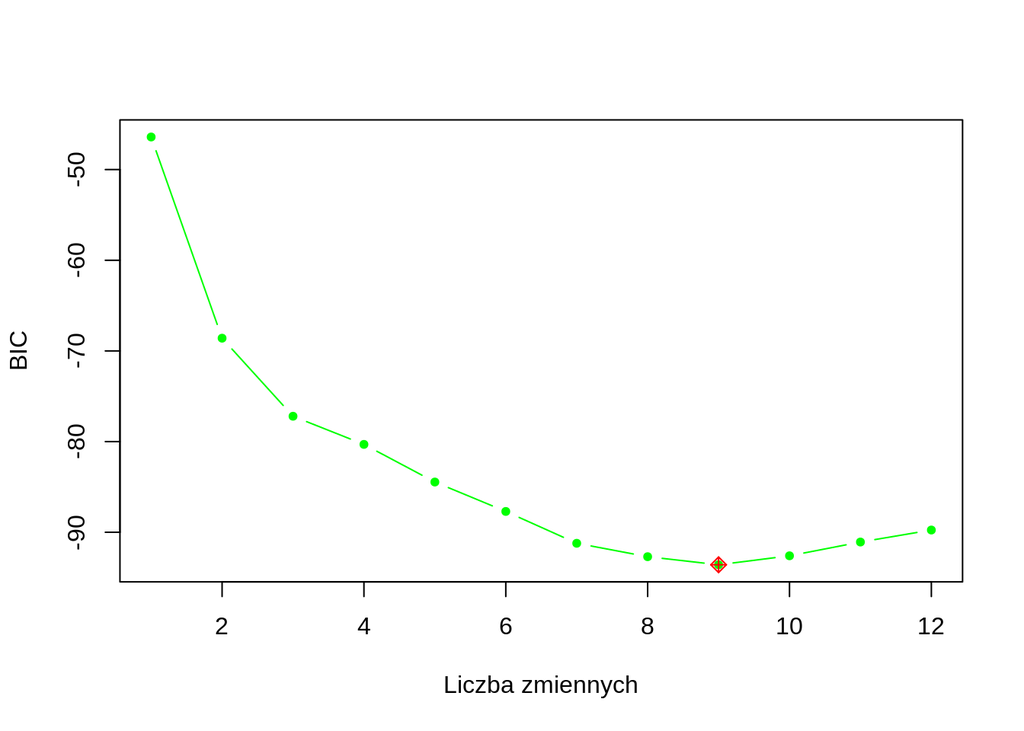

```r
plot(fit.bs.summary$bic, xlab = "Liczba zmiennych", ylab = "BIC", col = "green",
     type = "b", pch = 20)
points(bic.min, fit.bs.summary$bic[bic.min], col = "red", pch = 9)
```

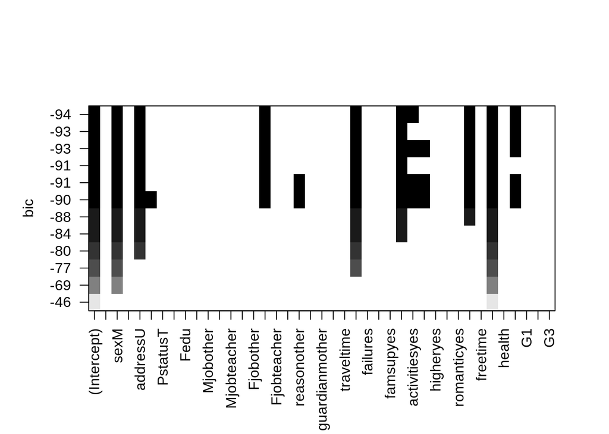

```r
plot(fit.bs, scale = "bic")
```

```r
coef(fit.bs, id = 9)
```

```
##   (Intercept)          sexM      addressU  Fjobservices     studytime
##    1.89278569    0.49383822   -0.36668632    0.32532249   -0.21673845
##       paidyes activitiesyes        famrel         goout      absences
##    0.29268933   -0.23724176   -0.15619796    0.34604221    0.01545319
```

```r
#bic Schwartz's information criterion, BIC
```

As we can see in the above analysis the best choice is to take 9 features namely: sexM, addressU, Fjobservices, studytime, paidyes, activitiesyes, famrel, goout, absences.

## Regularization GLMNET

Preparing variables

```r
library(glmnet)
X <- model.matrix(alc ~ ., data = data)[, -1]
y <- data$alc > 2
```

```r
print(head(data,3))
```

```
##   school sex age address famsize Pstatus Medu Fedu    Mjob    Fjob reason
## 1     GP   F  18       U     GT3       A    4    4 at_home teacher course
## 2     GP   F  17       U     GT3       T    1    1 at_home   other course
## 3     GP   F  15       U     LE3       T    1    1 at_home   other  other
##   guardian traveltime studytime failures schoolsup famsup paid activities
## 1   mother          2         2        0       yes     no   no         no
## 2   father          1         2        0        no    yes   no         no
## 3   mother          1         2        3       yes     no  yes         no
##   nursery higher internet romantic famrel freetime goout health absences G1 G2
## 1     yes    yes       no       no      4        3     4      3        6  5  6
## 2      no    yes      yes       no      5        3     3      3        4  5  5
## 3     yes    yes      yes       no      4        3     2      3       10  7  8
##   G3 alc
## 1  6   1
## 2  6   1
## 3 10   3
```

Features which we want to predict

```r
print(head(y,3))
```

```
## [1] FALSE FALSE  TRUE
```

```r
print(head(X,3))
```

```
##   schoolMS sexM age addressU famsizeLE3 PstatusT Medu Fedu Mjobhealth Mjobother
## 1        0    0  18        1          0        0    4    4          0         0
## 2        0    0  17        1          0        1    1    1          0         0
## 3        0    0  15        1          1        1    1    1          0         0
##   Mjobservices Mjobteacher Fjobhealth Fjobother Fjobservices Fjobteacher
## 1            0           0          0         0            0           1
## 2            0           0          0         1            0           0
## 3            0           0          0         1            0           0
##   reasonhome reasonother reasonreputation guardianmother guardianother
## 1          0           0                0              1             0
## 2          0           0                0              0             0
## 3          0           1                0              1             0
##   traveltime studytime failures schoolsupyes famsupyes paidyes activitiesyes
## 1          2         2        0            1         0       0             0
## 2          1         2        0            0         1       0             0
## 3          1         2        3            1         0       1             0
##   nurseryyes higheryes internetyes romanticyes famrel freetime goout health
## 1          1         1           0           0      4        3     4      3
## 2          0         1           1           0      5        3     3      3
## 3          1         1           1           0      4        3     2      3
##   absences G1 G2 G3
## 1        6  5  6  6
## 2        4  5  5  6
## 3       10  7  8 10
```

(grzbietowa)

```r
lambda.grid <- 10^seq(10, -2, length.out = 100)
fit.ridge <- glmnet(X, y, alpha = 0, lambda = lambda.grid)
set.seed(1)
n <- nrow(X)
train <- sample(1:n, n / 2)
test <- -train
fit.ridge <- glmnet(X[train,], y[train], alpha = 0, lambda = lambda.grid,
                    thresh = 1e-12)
```

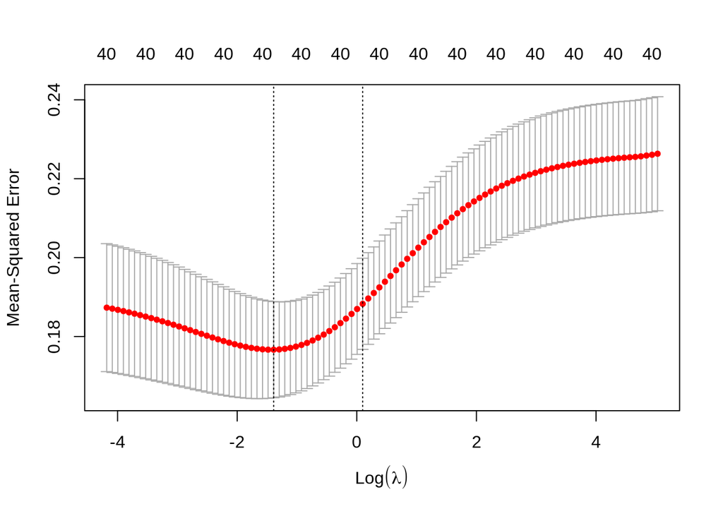

```r
set.seed(1)
cv.out <- cv.glmnet(X[train,], y[train], alpha = 0)
plot(cv.out)
```

```r
cv.out$lambda.min
```

```
## [1] 0.2490159
```

Minimal lambda

```r
pred.ridge <- predict(fit.ridge, s = cv.out$lambda.min, newx = X[test,])
mean((pred.ridge - y[test])^2)
```

```
## [1] 0.1778709
```

Square error 0.17 in thic case means that only 60% of cases were properly classfied. (we need to make root to calculate accuracy)

Least squares method

```r
pred.ridge <- predict(fit.ridge, s = 0, newx = X[test,])
mean((pred.ridge - y[test])^2)
```

```
## [1] 0.2012675
```

Somehow we have better results for λ=1

```r
pred.ridge <- predict(fit.ridge, s = 1, newx = X[test,])
mean((pred.ridge - y[test])^2)
```

```
## [1] 0.1774201
```

```r
fit.ridge.full <- glmnet(X, y, alpha = 0)
predict(fit.ridge.full, s = cv.out$lambda.min, type = "coefficients")
```

```
## 41 x 1 sparse Matrix of class "dgCMatrix"
##                              1
## (Intercept)       0.1792087179
## schoolMS          0.0216593604
## sexM              0.0960023870
## age               0.0022305556
## addressU         -0.0749992001
## famsizeLE3        0.0473117184
## PstatusT         -0.0301413703
## Medu             -0.0033945921
## Fedu              0.0151694428
## Mjobhealth       -0.0147547546
## Mjobother        -0.0196119254
## Mjobservices     -0.0225238737
## Mjobteacher      -0.0032915227
## Fjobhealth       -0.0097319182
## Fjobother         0.0152051536
## Fjobservices      0.0466416577
## Fjobteacher      -0.0645451661
## reasonhome        0.0218398851
## reasonother       0.0996526617
## reasonreputation -0.0421979030
## guardianmother   -0.0432077327
## guardianother    -0.0564259763
## traveltime        0.0380361669
## studytime        -0.0398435158
## failures          0.0311435659
## schoolsupyes     -0.0045105081
## famsupyes        -0.0121262727
## paidyes           0.0417008583
## activitiesyes    -0.0446224341
## nurseryyes       -0.0258774393
## higheryes        -0.0620489666
## internetyes       0.0011560305
## romanticyes      -0.0484876238
## famrel           -0.0428461122
## freetime          0.0264632603
## goout             0.0866013561
## health            0.0158555152
## absences          0.0054357999
## G1               -0.0064046408
## G2                0.0006351863
## G3                0.0019419243
```

```r
fit.ridge.full <- glmnet(X, y, alpha = 0)
predict(fit.ridge.full, s = 1, type = "coefficients")
```

```
## 41 x 1 sparse Matrix of class "dgCMatrix"
##                              1
## (Intercept)       0.2213381409
## schoolMS          0.0216153720
## sexM              0.0537878152
## age               0.0035955494
## addressU         -0.0353542737
## famsizeLE3        0.0256677929
## PstatusT         -0.0150184523
## Medu             -0.0012319867
## Fedu              0.0050335120
## Mjobhealth       -0.0001772039
## Mjobother        -0.0070548274
## Mjobservices     -0.0061656024
## Mjobteacher       0.0025587889
## Fjobhealth       -0.0102925523
## Fjobother         0.0047806617
## Fjobservices      0.0207661166
## Fjobteacher      -0.0300931801
## reasonhome        0.0109764787
## reasonother       0.0513939591
## reasonreputation -0.0290207214
## guardianmother   -0.0149723187
## guardianother    -0.0193569267
## traveltime        0.0221769806
## studytime        -0.0269850874
## failures          0.0193574601
## schoolsupyes     -0.0077318700
## famsupyes        -0.0086049832
## paidyes           0.0152385189
## activitiesyes    -0.0199853225
## nurseryyes       -0.0128476270
## higheryes        -0.0471793080
## internetyes       0.0021140801
## romanticyes      -0.0217065158
## famrel           -0.0190819519
## freetime          0.0173721952
## goout             0.0428876572
## health            0.0079970788
## absences          0.0026545358
## G1               -0.0034819978
## G2               -0.0008083942
## G3                0.0001083390
```

#Lasso

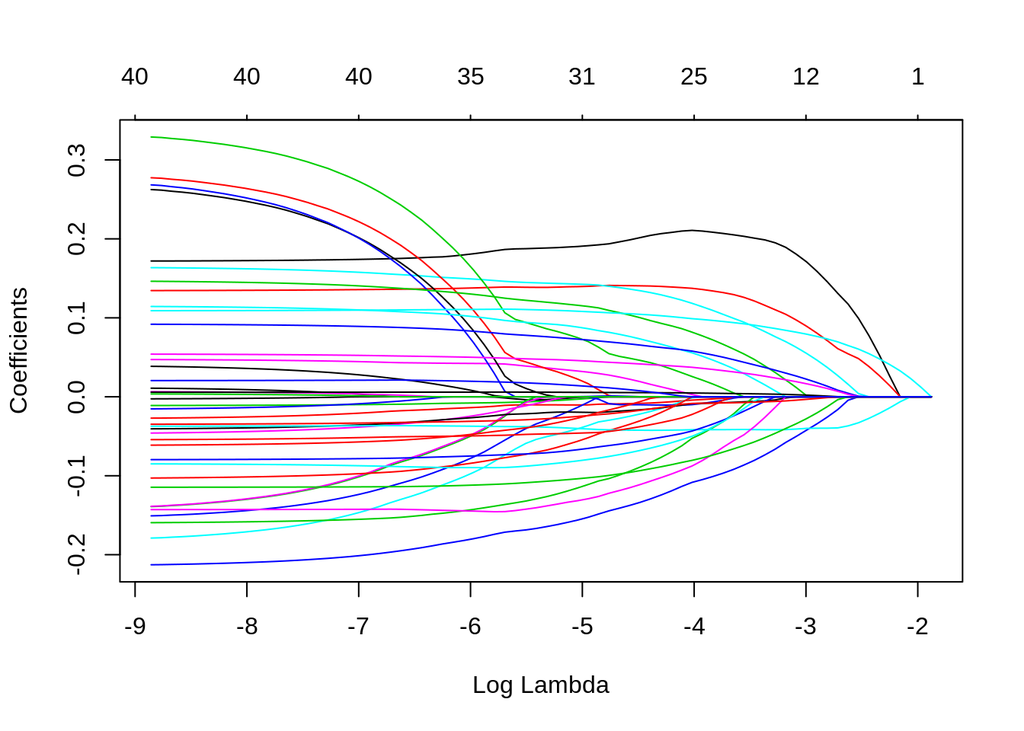

```r
fit.lasso <- glmnet(X[train,], y[train], alpha = 1)
plot(fit.lasso, xvar = "lambda")
```

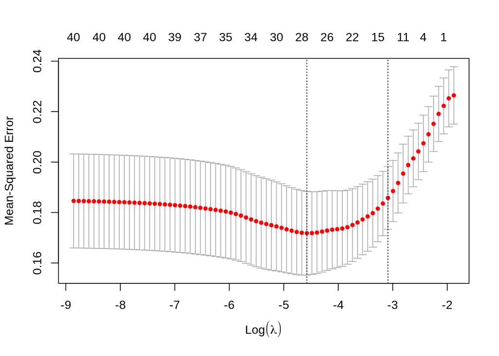

```r
cv.out <- cv.glmnet(X[train,], y[train], alpha = 1)
plot(cv.out)
```

```r
cv.out$lambda.min
```

```
## [1] 0.01028937
```

```r
pred.lasso <- predict(fit.lasso, s = cv.out$lambda.min, newx = X[test,])
mean((pred.lasso - y[test])^2)
```

```
## [1] 0.1842603
```

blad 0.18 means 43% failours in prediction

```r
fit.lasso.full <- glmnet(X, y, alpha = 1)
predict(fit.lasso.full, s = cv.out$lambda.min, type = "coefficients")[1:20,]
```

```
##      (Intercept)         schoolMS             sexM              age
##      0.130602375      0.000000000      0.131553426      0.000000000
##         addressU       famsizeLE3         PstatusT             Medu
##     -0.105293460      0.048452737     -0.003199608      0.000000000
##             Fedu       Mjobhealth        Mjobother     Mjobservices
##      0.003735956      0.000000000      0.000000000     -0.001077729
##      Mjobteacher       Fjobhealth        Fjobother     Fjobservices
##      0.000000000      0.000000000      0.000000000      0.043142145
##      Fjobteacher       reasonhome      reasonother reasonreputation
##     -0.067146188      0.003030598      0.117287961     -0.049513603
```

#Step function

step funcion for absences

```r
#X y
dataTmp <- data
attach(dataTmp)
dataTmp$alc <- dataTmp$alc > 2


absences.lims <- range(absences)
absences.grid <- seq(absences.lims[1], absences.lims[2])

#print(data$absences)
table(cut(absences, breaks = 6))
```

```
##
## (-0.075,12.5]     (12.5,25]     (25,37.5]     (37.5,50]     (50,62.5]
##           344            43             3             2             2
##   (62.5,75.1]
##             1
```

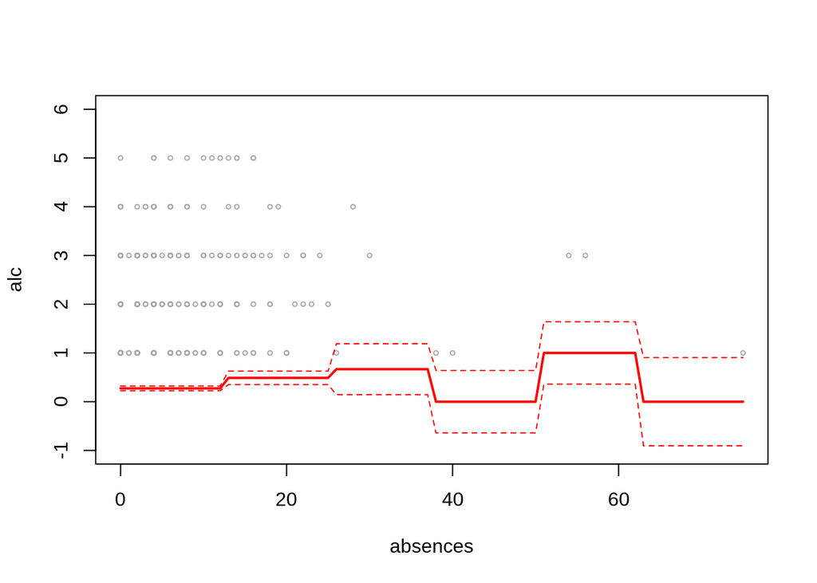

```r
fit.step <- lm(alc ~ cut(absences, 6), data = dataTmp)
pred.step <- predict(fit.step, list(absences = absences.grid), se.fit = TRUE)
se.bands <- cbind(pred.step$fit + 2 * pred.step$se.fit,
                  pred.step$fit - 2 * pred.step$se.fit)
plot(absences, alc, col = "darkgrey", cex = 0.5, xlim = absences.lims,ylim = c(-1,6))
lines(absences.grid, pred.step$fit, col = "red", lwd = 2)
matlines(absences.grid, se.bands, col = "red", lty = "dashed")
```

```r
detach(dataTmp)
```

Steps based on absences, we can see that majority of students has less than 13 absences.

```r
attach(dataTmp)
age.lims <- range(age)
age.grid <- seq(age.lims[1], age.lims[2])

studytime.lims <- range(studytime)
studytime.grid <- seq(studytime.lims[1], studytime.lims[2])

detach(dataTmp)
```

step function for age

```r
#X y
attach(dataTmp)
age.lims <- range(age)
age.grid <- seq(age.lims[1], age.lims[2])

#print(data$age)
table(cut(age, breaks = 6))
```

```
##
##   (15,16.2] (16.2,17.3] (17.3,18.5] (18.5,19.7] (19.7,20.8]   (20.8,22]
##         186          98          82          24           3           2
```

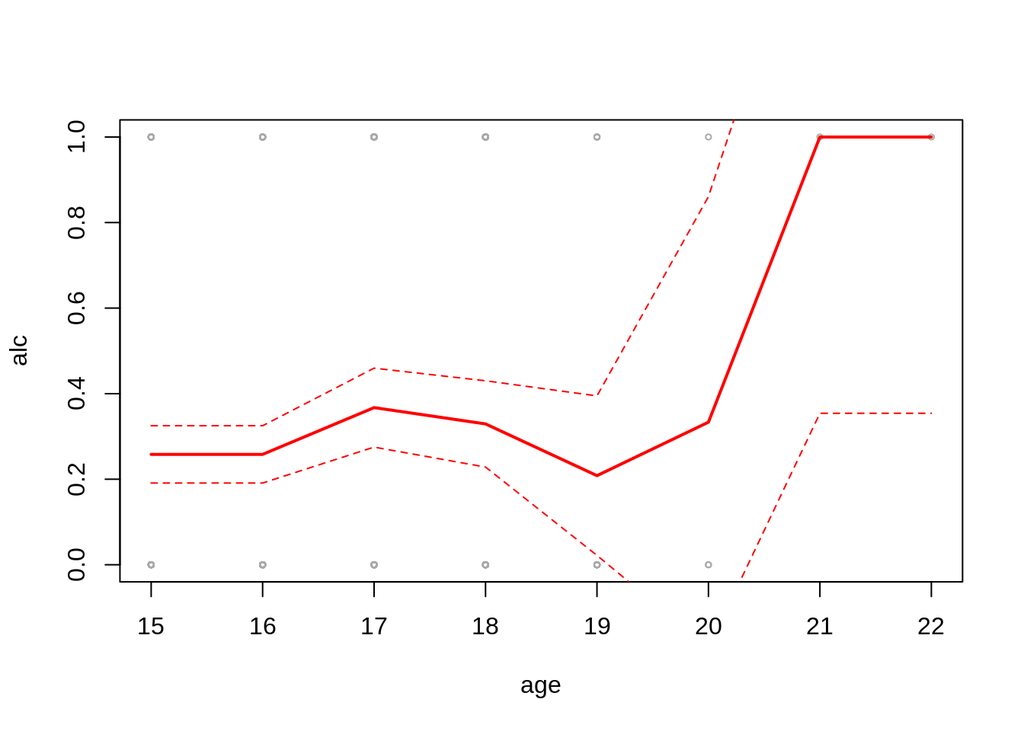

```r
fit.step <- lm(alc ~ cut(age, 6), data = dataTmp)
pred.step <- predict(fit.step, list(age = age.grid), se.fit = TRUE)
se.bands <- cbind(pred.step$fit + 2 * pred.step$se.fit,
                  pred.step$fit - 2 * pred.step$se.fit)
plot(age, alc, col = "darkgrey", cex = 0.5, xlim = age.lims)
lines(age.grid, pred.step$fit, col = "red", lwd = 2)
matlines(age.grid, se.bands, col = "red", lty = "dashed")
```

```r
#plot(age,alc)
detach(dataTmp)
```

##Natural splines

###Absences

```r
library(splines)
attach(data)
fit.ns <- lm(alc ~ ns(absences, df = 4), data = data)
pred.ns <- predict(fit.ns, list(absences = absences.grid), se.fit = TRUE)
```

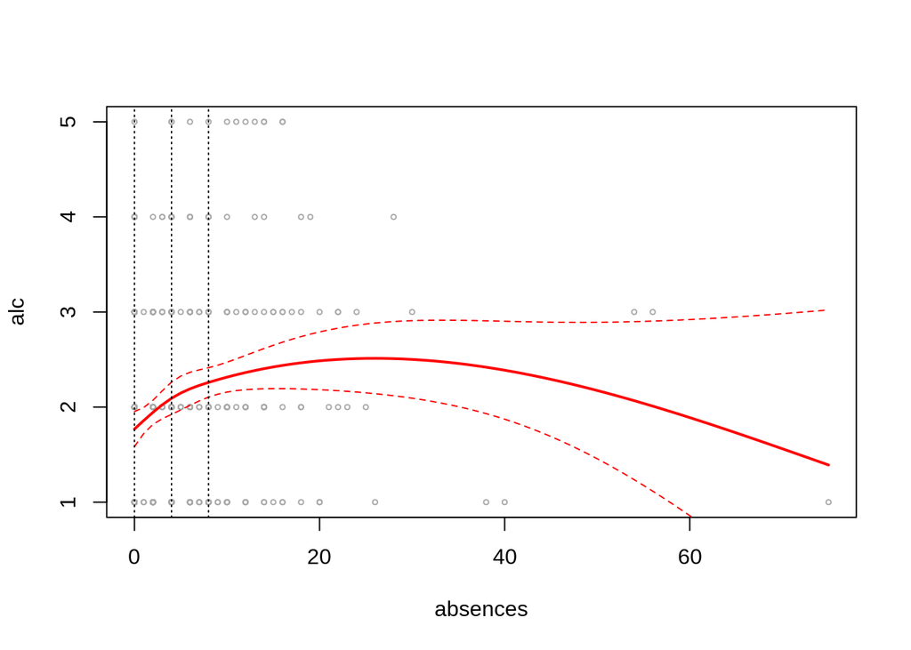

```r
plot(absences, alc, cex = 0.5, col = "darkgrey")
lines(absences.grid, pred.ns$fit, col = "red", lwd = 2)
lines(absences.grid, pred.ns$fit + 2 * pred.ns$se.fit, col = "red",
      lty = "dashed")
lines(absences.grid, pred.ns$fit - 2 * pred.ns$se.fit, col = "red",
      lty = "dashed")
abline(v = attr(ns(absences, df = 4), "knots"), lty = "dotted")
```

```r
detach(data)
```

###Studytime

```r
library(splines)
attach(data)
fit.ns <- lm(alc ~ ns(studytime, df = 4), data = data)
pred.ns <- predict(fit.ns, list(studytime = studytime.grid), se.fit = TRUE)
```

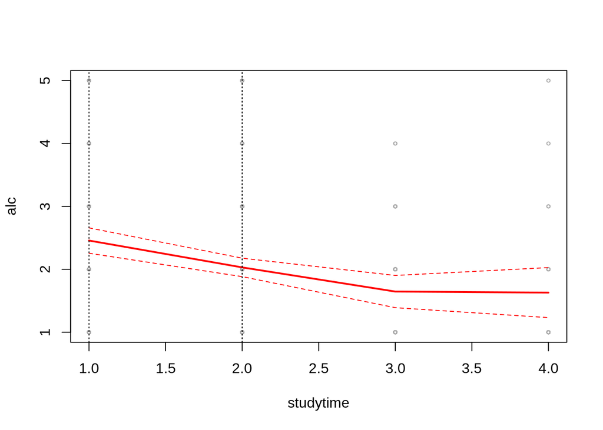

```r
plot(studytime, alc, cex = 0.5, col = "darkgrey")
lines(studytime.grid, pred.ns$fit, col = "red", lwd = 2)
lines(studytime.grid, pred.ns$fit + 2 * pred.ns$se.fit, col = "red",
      lty = "dashed")
lines(studytime.grid, pred.ns$fit - 2 * pred.ns$se.fit, col = "red",
      lty = "dashed")
abline(v = attr(ns(studytime, df = 4), "knots"), lty = "dotted")
```

```r
detach(data)
```

##Decision Trees ###First we are going to classiffy simply high or low consumption

```r
attach(data)

library(tree)
# <= 1 daje 25%
# <= 2 daje 17%
# <= 3 daje 7%

High <- factor(ifelse(alc <= 2, "No", "Yes"))
alcH <- data.frame(alc,High)

alc.high.tree <- tree(High ~ . - alc, data = data)
summary(alc.high.tree)
```

```
##
## Classification tree:
## tree(formula = High ~ . - alc, data = data)
## Variables actually used in tree construction:
##  [1] "goout"      "absences"   "freetime"   "activities" "reason"
##  [6] "G3"         "Medu"       "G2"         "Mjob"       "guardian"
## [11] "address"    "sex"        "famrel"     "G1"
## Number of terminal nodes:  20
## Residual mean deviance:  0.7292 = 273.4 / 375
## Misclassification error rate: 0.157 = 62 / 395
```

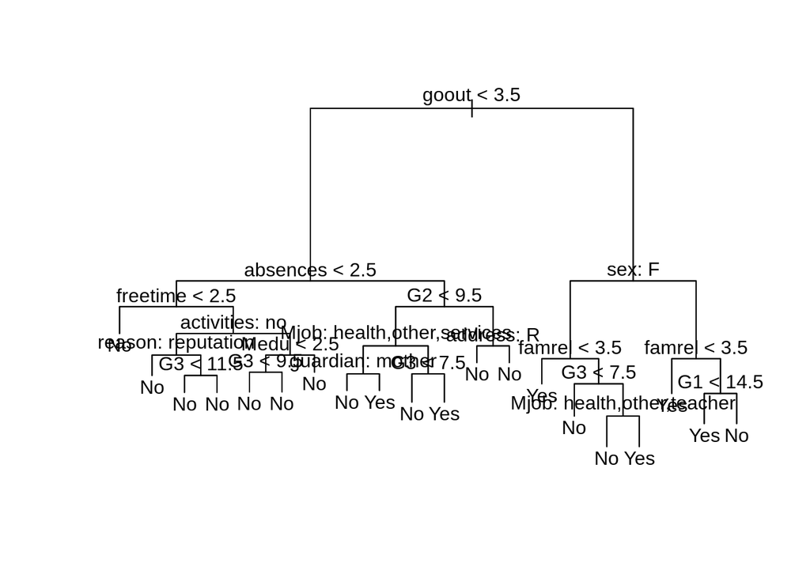

```r
plot(alc.high.tree)
text(alc.high.tree, pretty = 0)
```

```r
detach(data)
```

```r
alc.high.tree
```

```
## node), split, n, deviance, yval, (yprob)
##       * denotes terminal node
##
##  1) root 395 483.400 No ( 0.69873 0.30127 )
##    2) goout < 3.5 256 238.000 No ( 0.82422 0.17578 )
##      4) absences < 2.5 128  88.370 No ( 0.89062 0.10938 )
##        8) freetime < 2.5 31   0.000 No ( 1.00000 0.00000 ) *
##        9) freetime > 2.5 97  80.070 No ( 0.85567 0.14433 )
##         18) activities: no 46  50.610 No ( 0.76087 0.23913 )
##           36) reason: reputation 10   0.000 No ( 1.00000 0.00000 ) *
##           37) reason: course,home,other 36  44.320 No ( 0.69444 0.30556 )
##             74) G3 < 11.5 20  16.910 No ( 0.85000 0.15000 ) *
##             75) G3 > 11.5 16  22.180 No ( 0.50000 0.50000 ) *
##         19) activities: yes 51  22.820 No ( 0.94118 0.05882 )
##           38) Medu < 2.5 22  17.530 No ( 0.86364 0.13636 )
##             76) G3 < 9.5 13   0.000 No ( 1.00000 0.00000 ) *
##             77) G3 > 9.5 9  11.460 No ( 0.66667 0.33333 ) *
##           39) Medu > 2.5 29   0.000 No ( 1.00000 0.00000 ) *
##      5) absences > 2.5 128 141.700 No ( 0.75781 0.24219 )
##       10) G2 < 9.5 41  56.230 No ( 0.56098 0.43902 )
##         20) Mjob: health,other,services 24  26.990 No ( 0.75000 0.25000 )
##           40) guardian: mother 17  12.320 No ( 0.88235 0.11765 ) *
##           41) guardian: father,other 7   9.561 Yes ( 0.42857 0.57143 ) *
##         21) Mjob: at_home,teacher 17  20.600 Yes ( 0.29412 0.70588 )
##           42) G3 < 7.5 5   5.004 No ( 0.80000 0.20000 ) *
##           43) G3 > 7.5 12   6.884 Yes ( 0.08333 0.91667 ) *
##       11) G2 > 9.5 87  73.380 No ( 0.85057 0.14943 )
##         22) address: R 18  22.910 No ( 0.66667 0.33333 ) *
##         23) address: U 69  45.300 No ( 0.89855 0.10145 ) *
##    3) goout > 3.5 139 192.100 Yes ( 0.46763 0.53237 )
##      6) sex: F 68  85.610 No ( 0.67647 0.32353 )
##       12) famrel < 3.5 14  18.250 Yes ( 0.35714 0.64286 ) *
##       13) famrel > 3.5 54  59.610 No ( 0.75926 0.24074 )
##         26) G3 < 7.5 15   0.000 No ( 1.00000 0.00000 ) *
##         27) G3 > 7.5 39  49.650 No ( 0.66667 0.33333 )
##           54) Mjob: health,other,teacher 25  21.980 No ( 0.84000 0.16000 ) *
##           55) Mjob: at_home,services 14  18.250 Yes ( 0.35714 0.64286 ) *
##      7) sex: M 71  82.480 Yes ( 0.26761 0.73239 )
##       14) famrel < 3.5 15   0.000 Yes ( 0.00000 1.00000 ) *
##       15) famrel > 3.5 56  71.740 Yes ( 0.33929 0.66071 )
##         30) G1 < 14.5 49  56.700 Yes ( 0.26531 0.73469 ) *
##         31) G1 > 14.5 7   5.742 No ( 0.85714 0.14286 ) *
```

Most important predicators are at the top of the tree and the ones which splits set into two subset of the closest size.

```r
attach(data)
set.seed(1)
n <- nrow(data)
train <- sample(1:n, 3*n / 4)
test <- -train
alc.high.tree <- tree(High ~ . - alc, data = data, subset = train)
tree.class <- predict(alc.high.tree, newdata = data[test,], type = "class")
table(tree.class, alcH$High[test])
```

```
##
## tree.class No Yes
##        No  59  14
##        Yes 11  15
```

```r
mean(tree.class != alcH$High[test])
```

```
## [1] 0.2525253
```

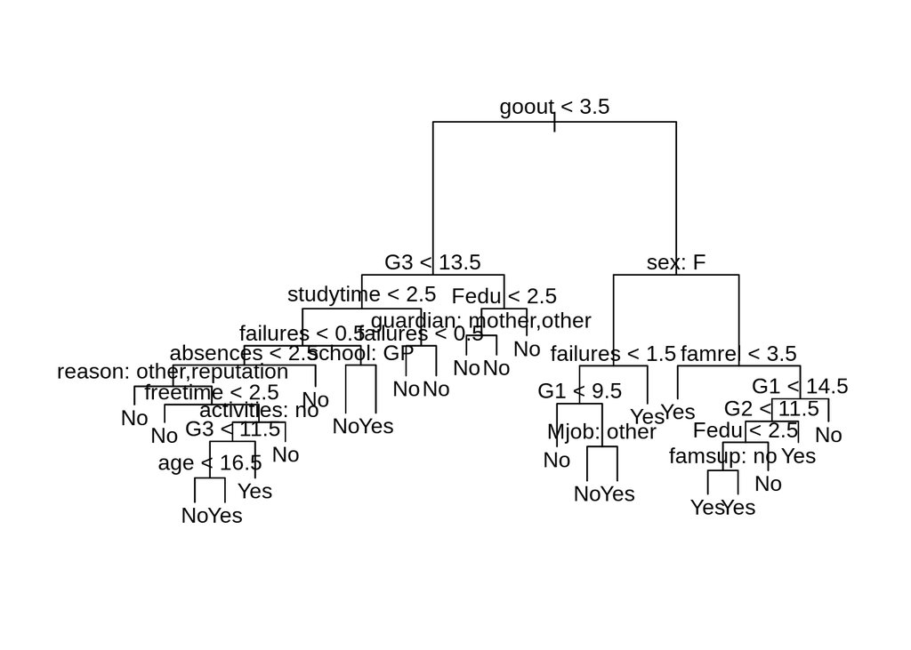

```r
plot(alc.high.tree)
text(alc.high.tree, pretty = 0)
```

```r
detach(data)
```

###pruning

```r
attach(data)
set.seed(1)
alc.high.cv <- cv.tree(alc.high.tree, FUN = prune.misclass)
alc.high.cv
```

```
## $size
## [1] 24 19 10  8  4  3  1
##
## $dev
## [1] 88 85 84 75 74 63 90
##
## $k
## [1]       -Inf  0.0000000  0.6666667  1.0000000  1.5000000  4.0000000 14.0000000
##
## $method
## [1] "misclass"
##
## attr(,"class")
## [1] "prune"         "tree.sequence"
```

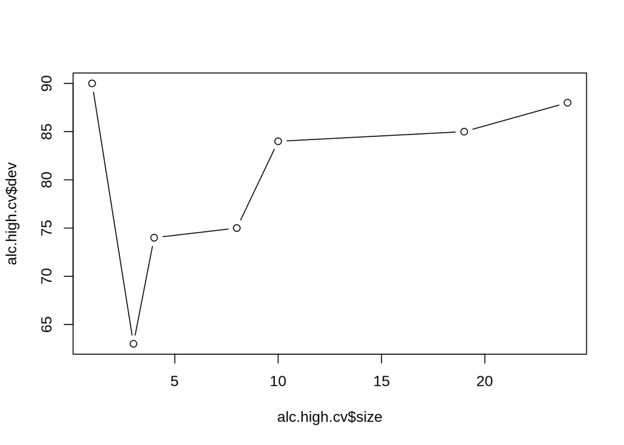

```r
plot(alc.high.cv$size, alc.high.cv$dev, type = "b")
```

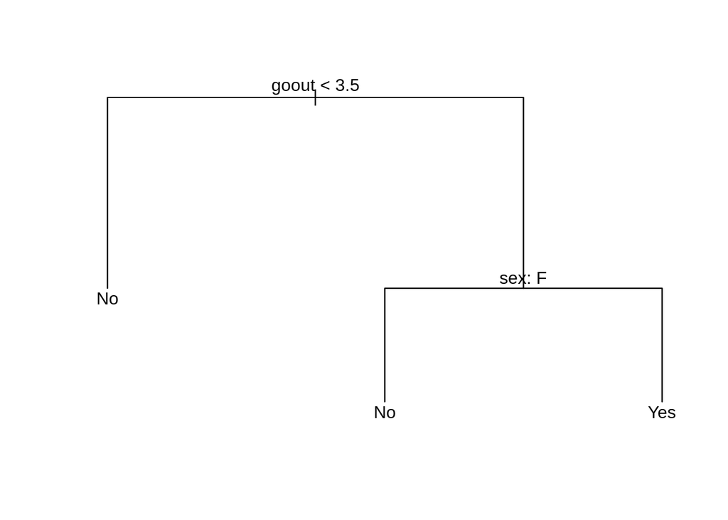

```r
size.opt <- alc.high.cv$size[which.min(alc.high.cv$dev)]
alc.high.pruned <- prune.misclass(alc.high.tree, best = size.opt)
plot(alc.high.pruned)
text(alc.high.pruned, pretty = 0)
```

```r
pruned.class <- predict(alc.high.pruned, newdata = data[test,],
                        type = "class")
table(pruned.class, alcH$High[test])
```

```
##
## pruned.class No Yes
##          No  64  18
##          Yes  6  11
```

```r
mean(pruned.class != alcH$High[test])
```

```
## [1] 0.2424242
```

```r
print(alc.high.pruned)
```

```
## node), split, n, deviance, yval, (yprob)
##       * denotes terminal node
##
## 1) root 296 363.60 No ( 0.6959 0.3041 )
##   2) goout < 3.5 199 191.10 No ( 0.8141 0.1859 ) *
##   3) goout > 3.5 97 133.60 Yes ( 0.4536 0.5464 )
##     6) sex: F 43  50.92 No ( 0.7209 0.2791 ) *
##     7) sex: M 54  59.61 Yes ( 0.2407 0.7593 ) *
```

```r
detach(data)
```

## Random forests

```r
attach(dataTmp)
library(randomForest)
alc.bag <- randomForest(alc ~ ., data = dataTmp, mtry = 3, importance = TRUE)
alc.bag
```

```
##
## Call:
##  randomForest(formula = alc ~ ., data = dataTmp, mtry = 3, importance = TRUE)
##                Type of random forest: regression
##                      Number of trees: 500
## No. of variables tried at each split: 3
##
##           Mean of squared residuals: 0.1704868
##                     % Var explained: 19.01
```

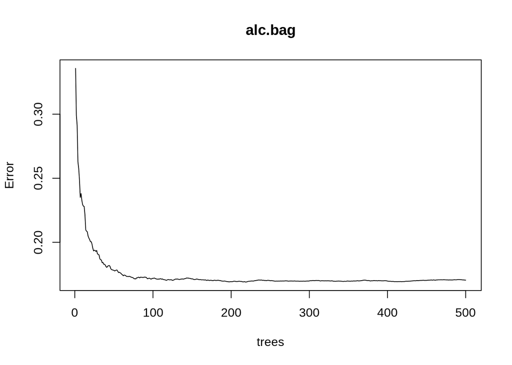

```r
plot(alc.bag, type = "l")
```

```r
importance(alc.bag)
```

```
##               %IncMSE IncNodePurity
## school      2.4944365     0.7773033
## sex        11.1371008     3.0211008
## age         0.7884593     2.5000450
## address     2.8526060     1.1819650
## famsize    -0.3086956     1.0010308
## Pstatus     0.6223895     0.5822473
## Medu        2.4855052     2.4496722
## Fedu       -1.4711709     2.0504332
## Mjob        2.0251725     3.2295063
## Fjob        0.2692342     2.3029818
## reason      2.7059018     3.6845234
## guardian   -0.7204186     1.4829960
## traveltime  4.8082248     2.3397171
## studytime   5.2307387     2.5606618
## failures    5.1272840     1.5337517
## schoolsup   0.1200378     0.6030041
## famsup      0.5194636     0.9266159
## paid       -0.2560083     1.0049919
## activities  1.5002563     1.0518212
## nursery     2.1219543     0.9380490
## higher      5.5294511     0.6843075
## internet    0.4811465     0.6916491
## romantic    1.5262936     0.9220043
## famrel      4.2177404     2.4667866
## freetime    2.9222618     2.5496763
## goout      18.8476469     7.1686975
## health      2.9482078     2.4502546
## absences    5.6112054     4.8059316
## G1          5.8210706     3.5756846
## G2          7.8585319     3.7595973
## G3          7.0768151     3.9112224
```

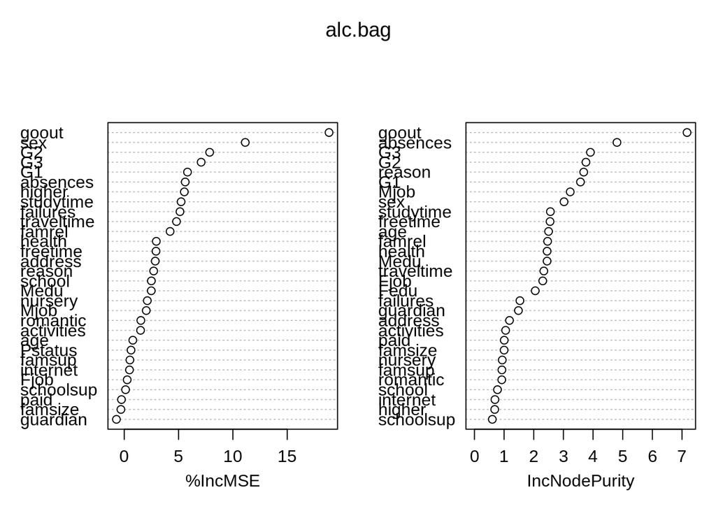

```r
varImpPlot(alc.bag)
```

```r
detach(dataTmp)
```

Lowest error is around 18% misclassyfication. There is no reason to have more than 150 trees.

# sprawdzenie ile zle sklasyfikowanych

```r
attach(dataTmp)
set.seed(1)
alc.bag <- randomForest(alc ~ ., data = dataTmp, subset = train, mtry = 3,
                         importance = TRUE,ntree = 250)
alc.pred.bag <- predict(alc.bag, newdata = dataTmp[test,])
mean((alc.pred.bag - dataTmp$alc[test])^2)
```

```
## [1] 0.1654365
```

```r
detach(dataTmp)
```

For 250 trees we can observe error rate around 16.5%.

```r
attach(dataTmp)
set.seed(2)
alc.bag.s <- randomForest(alc ~ ., data = dataTmp, subset = train, mtry = 3,
                         importance = TRUE, ntree = 70)
alc.pred.bag <- predict(alc.bag.s, newdata = dataTmp[test,])
mean((alc.pred.bag - dataTmp$alc[test])^2)
```

```
## [1] 0.1710457
```

```r
detach(dataTmp)
```

```r
attach(dataTmp)
set.seed(2)
alc.bag.s <- randomForest(alc ~ ., data = dataTmp, subset = train, mtry = 3,
                         importance = TRUE, ntree = 10)
alc.pred.bag <- predict(alc.bag.s, newdata = dataTmp[test,])
mean((alc.pred.bag - dataTmp$alc[test])^2)
```

```
## [1] 0.1642662
```

```r
detach(dataTmp)
```